# An Analysis of Professional Valorant Statistics

## Introduction

Valorant is a 5v5 character-based tactical shooter released in 2020 by Riot Games. In similar fashion to the tactical shooter CS:GO, Valorant games are composed of two teams: an attacking team and a defending team. A standard game is structured in rounds -- the first team to win 13 rounds wins the game. To win a round, the Attackers must eliminate the Defenders or plant a bomb (called the "spike") in an area called a plant site. Once planted, they must also defend it from being defused until it explodes. The Defenders either must eliminate all of the Attackers before they plant the spike or defuse it to win the round. Unlike CS:GO, Valorant offers a selection of 19 characters (called agents) with different abilities that spice up gameplay. Each agent belongs to one of 4 classes: duelists, initiators, controllers, and sentinels. Typically, professional Valorant matches consist of a best-of-3 or best-of-1 games on different maps.

We'll be scraping data, cleaning it up, then performing some visualization and analysis on it. In this tutorial, we're aiming to have some sort of new insight about the relationship between Valorant agents and the interactions between agents and maps. To get started, we need to import our tools.

## Necessary imports

We'll be using [NumPy](https://numpy.org), [Pandas](https://pandas.pydata.org/), [matplotlib](https://matplotlib.org/stable/index.html) + [seaborn](https://seaborn.pydata.org/index.html), [sklearn](https://scikit-learn.org/stable/), [requests](https://docs.python-requests.org/en/latest/), and [BeautifulSoup](https://www.crummy.com/software/BeautifulSoup/bs4/doc/#).

```python
import numpy as np
import pandas as pd
import matplotlib.pyplot as plt
import seaborn as sns
from sklearn.neighbors import KNeighborsClassifier
from sklearn.model_selection import train_test_split
import requests
from bs4 import BeautifulSoup
```

## Data scraping and wrangling

To begin, we're going to define a function that scrapes the most recent pro player stats off of vlr.gg, a website that covers all official Valorant esport events. It will return a DataFrame. The data we'll be scraping is a list of pro and semi-pro Valorant players' statistics - the exact page this is scraping off of can be found [here](https://www.vlr.gg/stats/?event_group_id=all&event_id=all&region=all&country=all&min_rounds=300&min_rating=1600&agent=all&map_id=all&timespan=all). To do this, we need to use `requests` for making a request to vlr.gg and `BeautifulSoup` to parse the HTML response. I've adapted this function from [axsddlr's vlrggapi](https://github.com/axsddlr/vlrggapi). It is modified to produce more accurate data, allow for more filters, and return a DataFrame instead of JSON.

```python
# We need to use these headers so vlr doesn't get angry
headers = {
    "User-Agent": "Mozilla/5.0 (X11; Ubuntu; Linux x86_64; rv:52.0) Gecko/20100101 Firefox/52.0",
}

# Allows us to put the map name in the data
id_to_map = {
    1: 'bind',
    2: 'haven',
    3: 'split',
    5: 'ascent',
    6: 'icebox',
    8: 'breeze',
    9: 'fracture',
}

# Returns a DataFrame of stats scraped from vlr.gg
def vlr_stats(region, agent="all", map_id="all", country="all"):
        # Formatted URL
        # We'll limit the required number of pro match rounds a player should have to 300
        # in order to get players with a decent amount of observations
        URL = f"https://www.vlr.gg/stats/?event_group_id=all&event_id=all&region={region}&country={country}&min_rounds=300" \
              f"&min_rating=1600&agent={agent}&map_id={map_id}&timespan=all"

        html = requests.get(URL, headers=headers)
        soup = BeautifulSoup(html.content)
        status = html.status_code

        if status != 200:
            raise Exception(f"API response: {status}")

        # Find the main table
        tbody = soup.find("tbody")
        # Get each row in the table
        containers = tbody.find_all("tr")

        data = []
        # loops through each row in the table
        for container in containers:
            # name of player
            player_container = container.find("td", {"class": "mod-player mod-a"})
            player = player_container.a.div.text.replace("\n", " ").strip()
            player = player.split(" ")[0]

            # rounds played
            rnd_container = container.find("td", {"class": "mod-rnd"})
            rnd = rnd_container.string

            # org name for player
            org_container = container.find("td", {"class": "mod-player mod-a"})
            org = org_container.a.div.text.replace("\n", " ").strip()
            org = org.split(" ")[-1]

            # stats for player
            stats_container = container.findAll("td", {"class": "mod-color-sq"})
            acs = stats_container[0].div.text.strip()
            kd = stats_container[1].div.text.strip()
            kast = stats_container[2].div.text.strip()
            adr = stats_container[3].div.text.strip()
            kpr = stats_container[4].div.text.strip()
            apr = stats_container[5].div.text.strip()
            fkpr = stats_container[6].div.text.strip()
            fdpr = stats_container[7].div.text.strip()
            hs = stats_container[8].div.text.strip()
            cl = stats_container[9].div.text.strip()

            # Represents one row of the table.

            data.append(
                [
                    player,
                    org,
                    # scraping means we're getting string representations of numbers,
                    # so we've got to convert to do analysis
                    int(rnd),
                    float(acs),
                    float(kd),
                    float(kast[:-1])/100 if kast != "" else np.nan,
                    float(adr),
                    float(kpr),
                    float(apr),
                    float(fkpr),
                    float(fdpr),
                    float(hs[:-1])/100 if hs != "" else np.nan,
                    float(cl[:-1])/100 if cl != "" else np.nan,
                    region,
                    agent,
                    id_to_map[map_id] if map_id != "all" else map_id,
                ]
            )

        result = pd.DataFrame(data, columns=[
            "player",
            "org",
            "rounds_played",
            "average_combat_score",
            "kill_deaths",
            "kast",
            "average_damage_per_round",
            "kills_per_round",
            "assists_per_round",
            "first_kills_per_round",
            "first_deaths_per_round",
            "headshot_percentage",
            "clutch_success_percentage",
            "region",
            "agent",
            "map"
        ])
        return result
```

Now let's compile some stats by region. We can use the function defined above to do this. For now, I've chosen to keep my search wide and consider all maps and agents.

```python
stats = {
    # North America
    "na": vlr_stats("na"),
    # Europe
    "eu": vlr_stats("eu"),
    # Asia-Pacific
    "ap": vlr_stats("ap"),
    # Latin America
    "sa": vlr_stats("sa"),
    # Japan
    "jp": vlr_stats("jp"),
    # Oceania
    "oce": vlr_stats("oce"),
    # MENA
    "mn": vlr_stats("mn"),
}
stats_all = pd.concat([stats["na"],stats["eu"],stats["ap"],stats["sa"],stats["jp"],stats["oce"],stats["mn"]], ignore_index=True)
stats_all
```

[output not shown]

What we've ended up with here is great, but let's dig a bit deeper and get some data filtered by agent and map.

```python
agents = ['jett', 'reyna', 'raze', 'breach', 'phoenix', 'chamber',
          'skye', 'sova', 'yoru', 'kayo', 'killjoy', 'neon', 'omen',
          'sage', 'brimstone', 'astra', 'viper', 'cypher', 'fade']
# Let's get some data by agent only
for agent in agents:
    stats[agent] = vlr_stats('all', agent=agent)
```

And while we're at it, by map and then by agent and map.

```python
maps = {'bind': 1, 'haven': 2, 'split': 3,  'ascent': 5, 'icebox': 6, 'breeze':8, 'fracture':9}
for (k,v) in maps.items():
    stats[k] = vlr_stats('all', map_id=v)
stats_all_maps = pd.concat([stats[k] for k in maps.keys()], ignore_index=True)
```

```python
temp = [] # Store each DataFrame here
for (k,v) in maps.items():
    for agent in agents:
        temp.append(vlr_stats('all', map_id=v, agent=agent))
stats_agent_map = pd.concat([df for df in temp], ignore_index=True)
stats_agent_map
```

|  | player | org | rounds_played | average_combat_score | kill_deaths | kast | average_damage_per_round | kills_per_round | assists_per_round | first_kills_per_round | first_deaths_per_round | headshot_percentage | clutch_success_percentage | region | agent | map |
| --- | --- | --- | --- | --- | --- | --- | --- | --- | --- | --- | --- | --- | --- | --- | --- | --- |
| 0 | Cryocells | XSET | 322 | 284.5 | 1.58 | 0.71 | 170.9 | 1.03 | 0.08 | 0.2 | 0.11 | 0.3 | 0.24 | all | jett | bind |
| 1 | JohnOlsen | FS | 342 | 278.8 | 1.52 | 0.74 | 179.9 | 0.99 | 0.15 | 0.21 | 0.13 | 0.28 | 0.2 | all | jett | bind |
| 2 | SkRossi | GES | 437 | 275.4 | 1.34 | 0.73 | 162.7 | 0.95 | 0.14 | 0.27 | 0.16 | 0.24 | 0.18 | all | jett | bind |
| 3 | TenZ | SEN | 401 | 266.1 | 1.4 | 0.76 | 170.2 | 0.94 | 0.18 | 0.22 | 0.11 | 0.21 | 0.35 | all | jett | bind |
| 4 | WARDELL | V1 | 389 | 259.9 | 1.48 | NaN | 161.5 | 0.93 | 0.15 | 0.2 | 0.09 | 0.21 | 0.11 | all | jett | bind |
| ... | ... | ... | ... | ... | ... | ... | ... | ... | ... | ... | ... | ... | ... | ... | ... | ... |
| 1057 | iyen | SQ | 318 | 189.9 | 1.01 | 0.77 | 128.3 | 0.67 | 0.26 | 0.1 | 0.08 | 0.18 | 0.22 | all | viper | breeze |
| 1058 | vanity | C9 | 337 | 175.6 | 0.91 | 0.72 | 114.4 | 0.6 | 0.35 | 0.09 | 0.09 | 0.17 | 0.14 | all | viper | breeze |
| 1059 | ryann | GHST | 366 | 173.9 | 0.9 | 0.74 | 121.1 | 0.62 | 0.31 | 0.08 | 0.1 | 0.3 | 0.24 | all | viper | breeze |
| 1060 | Jangler | TB | 381 | 167.6 | 0.89 | 0.7 | 110.2 | 0.66 | 0.29 | 0.04 | 0.05 | 0.24 | 0.11 | all | viper | breeze |
| 1061 | hellff | VLT | 336 | 199.3 | 1.11 | 0.65 | 133.9 | 0.73 | 0.19 | 0.07 | 0.07 | 0.27 | 0.21 | all | cypher | breeze |

1062 rows × 16 columns

```python
stats_all_maps
```

|  | player | org | rounds_played | average_combat_score | kill_deaths | kast | average_damage_per_round | kills_per_round | assists_per_round | first_kills_per_round | first_deaths_per_round | headshot_percentage | clutch_success_percentage | region | agent | map |
| --- | --- | --- | --- | --- | --- | --- | --- | --- | --- | --- | --- | --- | --- | --- | --- | --- |
| 0 | sociablEE | FF | 317 | 286.7 | 1.37 | 0.8 | 186.1 | 0.99 | 0.22 | 0.21 | 0.15 | 0.22 | 0.08 | all | all | bind |
| 1 | TenZ | SEN | 885 | 276.2 | 1.45 | 0.76 | 172.2 | 0.97 | 0.23 | 0.21 | 0.11 | 0.19 | 0.32 | all | all | bind |
| 2 | keznit | KRÜ | 452 | 275.1 | 1.2 | 0.75 | 167.2 | 0.9 | 0.25 | 0.2 | 0.14 | 0.18 | 0.09 | all | all | bind |
| 3 | trexx | GLD | 316 | 270.8 | 1.4 | 0.76 | 172.5 | 0.94 | 0.36 | 0.14 | 0.1 | 0.2 | 0.21 | all | all | bind |
| 4 | SkRossi | GES | 649 | 268.8 | 1.34 | 0.72 | 161.1 | 0.95 | 0.14 | 0.24 | 0.16 | 0.22 | 0.19 | all | all | bind |
| ... | ... | ... | ... | ... | ... | ... | ... | ... | ... | ... | ... | ... | ... | ... | ... | ... |
| 2544 | Ange | DZ | 427 | 166.2 | 0.89 | 0.71 | 105.8 | 0.59 | 0.22 | 0.04 | 0.05 | 0.27 | 0.15 | all | all | breeze |
| 2545 | L1NK | TL | 333 | 164.5 | 1.0 | 0.7 | 120.3 | 0.58 | 0.19 | 0.05 | 0.05 | 0.32 | 0.15 | all | all | breeze |
| 2546 | Stronglegs | GKS | 357 | 158.4 | 0.73 | 0.62 | 105.2 | 0.54 | 0.35 | 0.06 | 0.1 | 0.23 | 0.07 | all | all | breeze |
| 2547 | evaD | evaD | 407 | 152.9 | 0.76 | 0.65 | 104.3 | 0.55 | 0.29 | 0.04 | 0.07 | 0.22 | 0.11 | all | all | breeze |
| 2548 | LeahPanda | TSM.X | 331 | 149.6 | 0.73 | 0.66 | 104.2 | 0.51 | 0.28 | 0.05 | 0.09 | 0.16 | 0.16 | all | all | breeze |

2549 rows × 16 columns

Now we can analyze based on what agent each player plays and what map they played on.

## Data visualization and analysis

For this part of the data lifecycle, we'll try and find some interesting relationships between player statistics on our data that includes all agents, maps, and regions. To do this, we'll use matplotlib with seaborn's `scatterplot()` and then fit a regression with `regplot()`.

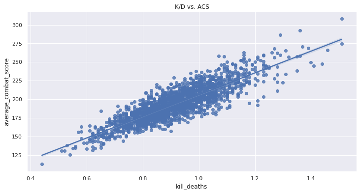

```python
sns.set_theme()
plt.figure(figsize=(12,6))
ax = sns.regplot(data=stats_all, x="kill_deaths", y="average_combat_score")
ax.set_title("K/D vs. ACS")
```

Firstly, we can see that a good predictor of a player's ACS (average combat score) is their kills to deaths ratio. This is expected, since ACS is calculated using K/D with other data. Maybe we can find other relationships that are more interesting.

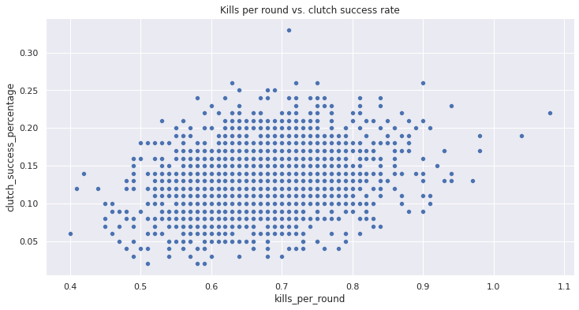

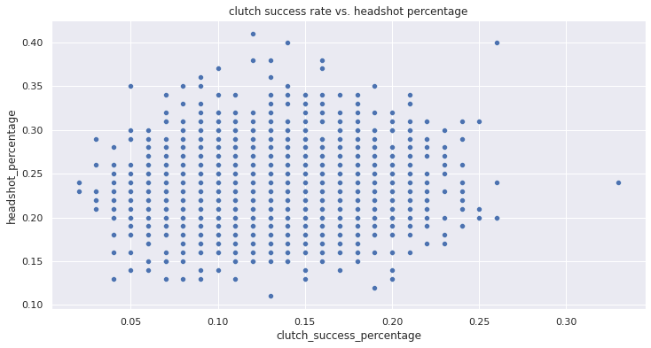

```python
plt.figure(figsize=(12,6))
ax = sns.scatterplot(data=stats_all, x="kills_per_round", y="clutch_success_percentage")
ax.set_title("Kills per round vs. clutch success rate")

plt.figure(figsize=(12,6))
ax = sns.scatterplot(data=stats_all, x="clutch_success_percentage", y="headshot_percentage")
ax.set_title("clutch success rate vs. headshot percentage")

plt.show()
```

Some observations: As a player's average kills per round increases, their clutch percentage also seems to increase. Intuitively, this makes sense. A clutch in Valorant happens when the last player on your team wins the round - usually this involves getting at least one kill during the round. Interestingly, we can also observe that a player's clutch success percentage does not seem to have any significant relationship with how often they hit headshots.

This is interesting, but maybe we can get some new insights into how player stats differ between depending on what agent is played. For this, let's first see how the mean ACS (average combat score) differs between agents. We'll use ACS since this is good stat to use to gauge the overall performance of a player. Which agents are better than others?

## Differences between agents

```python
agent_means=stats_agent_map.groupby('agent')[['average_combat_score', 'assists_per_round', 'kills_per_round']].mean()
agent_means
```

| agent | average_combat_score | assists_per_round | kills_per_round |
| --- | --- | --- | --- |
| astra | 191.394366 | 0.311127 | 0.692676 |
| breach | 177.880952 | 0.368095 | 0.641429 |
| brimstone | 197.428571 | 0.308571 | 0.682857 |
| chamber | 222.116667 | 0.143333 | 0.813333 |
| cypher | 193.812500 | 0.228036 | 0.691071 |
| jett | 233.727706 | 0.156190 | 0.824545 |
| kayo | 200.000000 | 0.418571 | 0.692857 |
| killjoy | 203.167470 | 0.182530 | 0.701325 |
| omen | 193.396610 | 0.271186 | 0.687458 |
| phoenix | 235.266667 | 0.275833 | 0.794167 |
| raze | 243.402353 | 0.232118 | 0.815176 |
| reyna | 237.468182 | 0.207727 | 0.821818 |
| sage | 198.581481 | 0.309630 | 0.709259 |
| skye | 192.424000 | 0.289600 | 0.677200 |
| sova | 200.374603 | 0.339960 | 0.675794 |
| viper | 196.200000 | 0.292958 | 0.685352 |

Unfortunately there is no data for Yoru or Neon, since they are rarely picked in professional play, and Fade, because she was only added to the game a few weeks ago (from the time I'm writing this). We'll be able to use barplots to visually see which agent has the highest average ACS, kills per round, and assists per round. I'll also go ahead and sort the data to make interpretation easier.

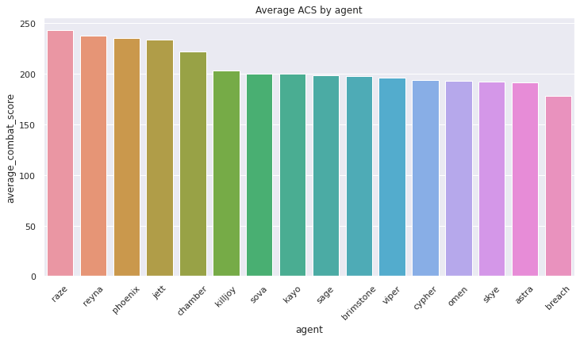

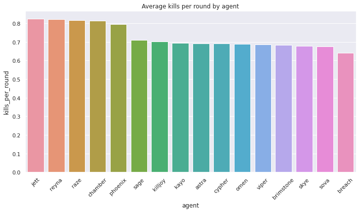

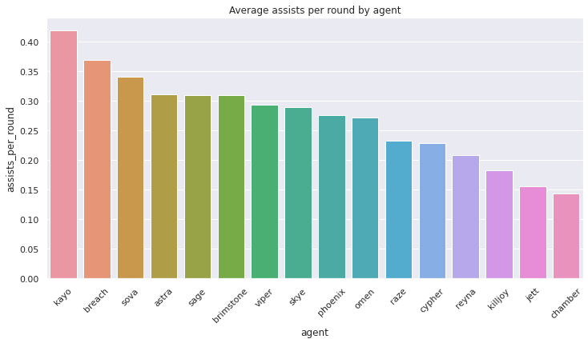

```python
# Lots of plots!
agent_means.sort_values('average_combat_score', inplace=True, ascending=False)
plt.figure(figsize=(12,6))
ax = sns.barplot(data=agent_means, x=agent_means.index, y='average_combat_score')
ax.set_title('Average ACS by agent')
plt.xticks(rotation=45)
agent_means.sort_values('kills_per_round', inplace=True, ascending=False)
plt.figure(figsize=(12,6))
ax = sns.barplot(data=agent_means, x=agent_means.index, y='kills_per_round')
ax.set_title('Average kills per round by agent')
plt.xticks(rotation=45)
plt.show()
agent_means.sort_values('assists_per_round', inplace=True, ascending=False)
plt.figure(figsize=(12,6))
ax = sns.barplot(data=agent_means, x=agent_means.index, y='assists_per_round')
ax.set_title('Average assists per round by agent')
plt.xticks(rotation=45)
plt.show()
```

We can see that players who played Reyna, Raze, Phoenix, or Jett on average have a higher ACS and kills per round than other players. This makes sense intuitively, as these characters (plus Yoru & Neon) make up the duelist agent class. In Valorant, agents fall into one of four differnent classes: duelists, sentinels, initiators, and controllers. According to the in-game description of duelists, they are "self-sufficient fraggers" (A "frag" in a tactical shooter is a kill). A duelist's role on the team is to ramp up aggression and get kills to allow their team to take control of a site -- we can see this characterization in the numbers. On the other hand, players who get lots of kill assists per round tend to play the agents that we saw had a lower ACS, the non-duelist agents. Since the data for assists per round by agent is a bit more interesting, let's dig deeper.

## Agent performance by map

Most players feel that there are certain agents that perform better than others for each map. Let's use our data that includes observations filtered on map and agent to see if there are any differences.

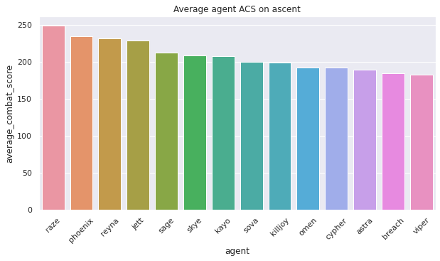

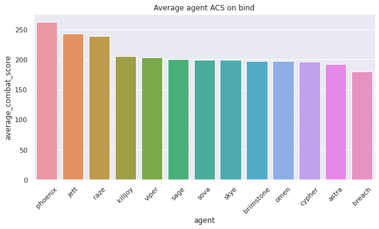

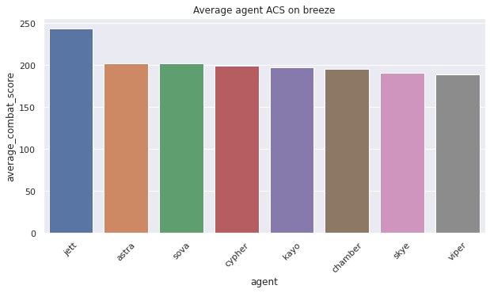

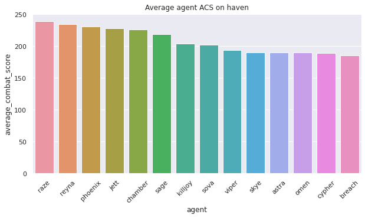

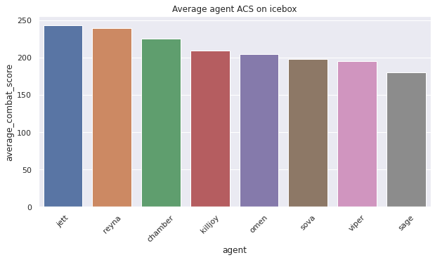

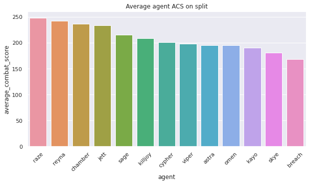

```python
# Loop through each map
for index, mapid in stats_agent_map.groupby('map'):
    plt.figure(figsize=(10,5))
    # Get the means of the average_combat_score column and assists_per_round column, then sort
    means = mapid.groupby('agent')[['average_combat_score', 'assists_per_round']].mean().sort_values('average_combat_score', ascending=False)
    ax = sns.barplot(data=means, x=means.index, y='average_combat_score')
    ax.set(title=f"Average agent ACS on {index}")
    plt.xticks(rotation=45)
    plt.show()
```

The first thing we notice is that not all of the plots show every agent -- this is because of the tight meta used by most teams on certain maps, like Icebox and Breeze. In other words, for these maps, pro teams only play the same few agents because they think they work the best for these particular maps. Regardless of the limited data, the agents at the top make sense. Regardless of the map played, the duelist agents have the highest ACS. Jett, Raze, and Reyna seem to always have the highest ACS compared to the other duelists. Interestingly, on Bind Phoenix has the highest ACS on average. Another notable character that isn't a duelist is Chamber. Chamber's ACS seems to trail just behind the duelists on most maps, and on Split he outperforms Jett. Apart from these observations, this is what was expected. Now let's plot mean assists_per_round by agent on each map.

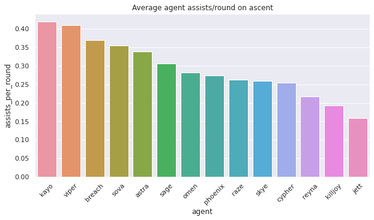

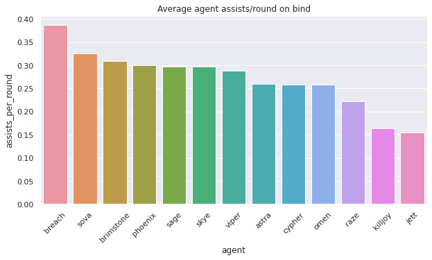

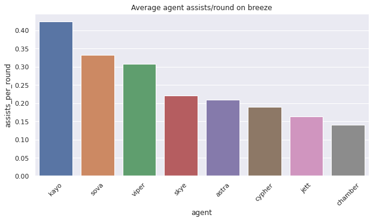

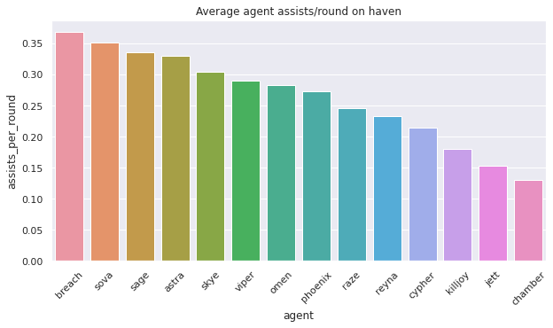

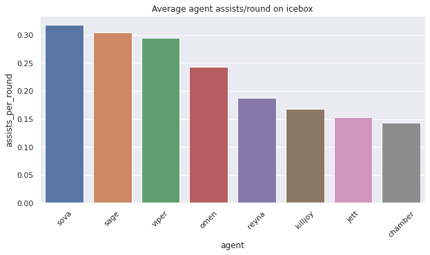

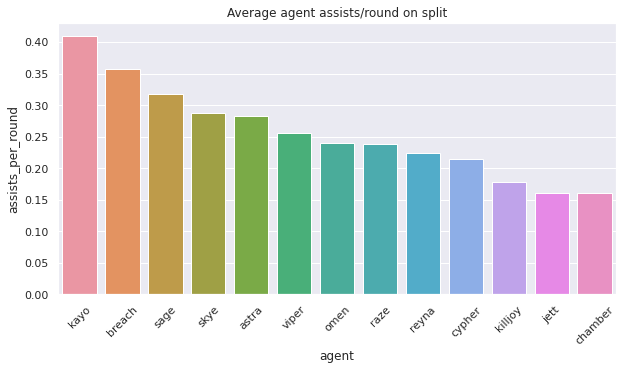

```python
# Loop through each map
for index, mapid in stats_agent_map.groupby('map'):
    plt.figure(figsize=(10,5))
    # Get the means of the average_combat_score column and assists_per_round column, then sort
    means = mapid.groupby('agent')[['average_combat_score', 'assists_per_round']].mean().sort_values('assists_per_round', ascending=False)
    ax = sns.barplot(data=means, x=means.index, y='assists_per_round')
    ax.set(title=f"Average agent assists/round on {index}")
    plt.xticks(rotation=45)
    plt.show()
```

We can see that the average assists per round on each map produces different results. Kayo has highest average assists per round on the maps Ascent, Breeze, and Split, while Breach has the highest on Bind and Haven. If we consider the abilities of Kayo and Breach, it makes sense. These agents have some of the best team-focused abilities in the game.

## Predicting agent played based on ACS and assists per round

To try and classify agents based on stats, we'll use a KNearestNeighbors classifier from sklearn.

```python
# Contains an array of features - we'll use ACS and assists
X = [[x[1]['average_combat_score'], x[1]['assists_per_round']] for x in stats_agent_map.iterrows()]
# The array of desired results, in this case a list of agents
y = [x[1]['agent'] for x in stats_agent_map.iterrows()]

# Split the data up to test and train
X_train, X_test, y_train, y_test = train_test_split(X, y, test_size=0.33)
m = KNeighborsClassifier(n_neighbors=10)
m.fit(X_train,y_train)
m.score(X_test, y_test)
```

```
0.2905982905982906
```

Our model isn't that great. Unfortunately, the agents pros play are not so easily predictable based on their stats alone- but this is understandable. In Valorant, gunplay is what's most important, and in that respect every agent is on a level playing field.

## Conclusion and further exploration

We've reaffirmed our suspicions with this analysis. The agents with the highest average combat score are duelists for each map - and the agents with the highest assists per round are know for their abilities that aid the team as a whole. Data I would have really loved to have for this analyis is win/loss data per player. Unfortunately, this was something I wasn't able to scrape off of vlr.gg. Having that would have enabled us to possibly gain insights into what agent is truly the best based off of win rate, or predict a player's win rate based off of their stats. Over time as Valorant matures, I'm sure we'll be able to get this data more easily. Thanks for reading!